# Exploring spatial data

## Introducing spatial data

## Spatial data types

- Vector data
  - represents space using points, lines and polygons (“features”)
  - each of these can have additional data (“attributes”)
  - R package `sf`
- Raster data
  - represents space using cells of equal size
  - each cell can have additional data (“layers”)
  - R package `raster`

## Vector data

## Raster data

## Simple features

## What is a feature?

- A **feature** is a thing… a city, a house, a tree
  - has a **geometry** describing where it is located
  - has **attributes** describing its other properties
- A feature may be made up of other features
  - pixel vs. image

## What are simple features?

- open standard for spatial data types
- points, lines and polygons = “geometries”
- geometries are hierarchical
  - set of points is a line
  - set of lines forms a polygon
  - several polygons is a multipolygon
- 17 geometries, of which we look at 7
- [“data frames with a spatial extension”](https://geocompr.robinlovelace.net/spatial-class.html#sfc)

## `sf` geometry types

- A point: `st_point()`
- A linestring: `st_linestring()`
- A polygon: `st_polygon()`
- A multipoint: `st_multipoint()`
- A multilinestring: `st_multilinestring()`
- A multipolygon: `st_multipolygon()`
- A geometry collection: `st_geometrycollection()`
- Can be created from vectors, matrices, or lists

## Features made of single geometries

```r
# POINT
(pt1 <- st_point(c(5, 2)))
```

```
## POINT (5 2)
```

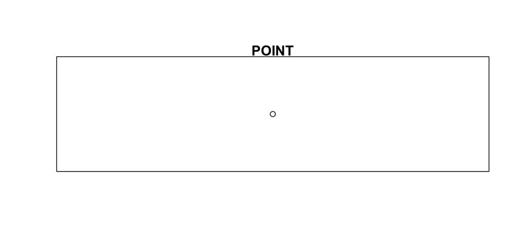

```r
# LINESTRING
(ls1 <- st_linestring(rbind(c(5, 2), c(1, 3), c(3, 4))))
```

```
## LINESTRING (5 2, 1 3, 3 4)
```

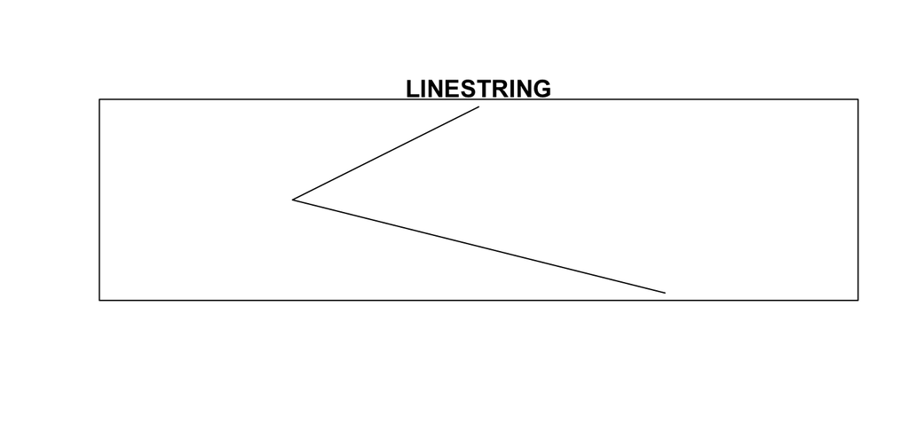

```r
# POLYGON
pl <- list(rbind(c(5, 2), c(1, 3), c(3, 4), c(5, 2)))
(poly1 <- st_polygon(pl))
```

```
## POLYGON ((5 2, 1 3, 3 4, 5 2))
```

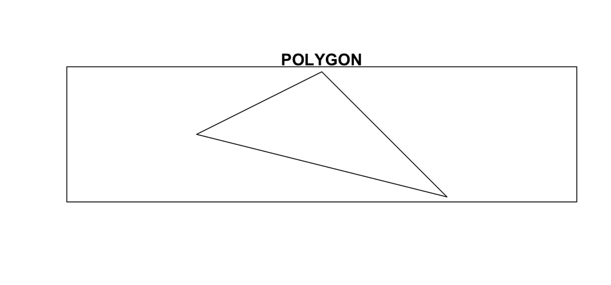

## Features made of multiple geometries

```r
# MULTIPOINT
mpmat <- rbind(c(5, 2), c(1, 3), c(3, 4))
(mp1 <- st_multipoint(mpmat))
```

```
## MULTIPOINT (5 2, 1 3, 3 4)
```

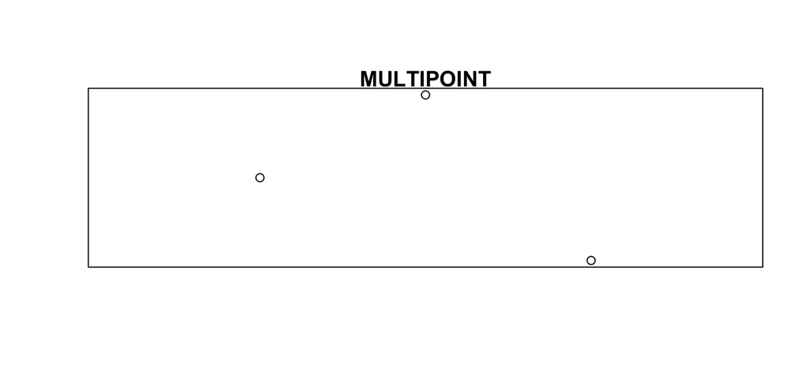

```r
# MULTILINESTRING
mll <- list(rbind(c(1, 5), c(4, 4), c(4, 1), c(2, 2)),
           rbind(c(1, 2), c(2, 4)))
(mls1 <- st_multilinestring((mll)))
```

```
## MULTILINESTRING ((1 5, 4 4, 4 1, 2 2), (1 2, 2 4))
```

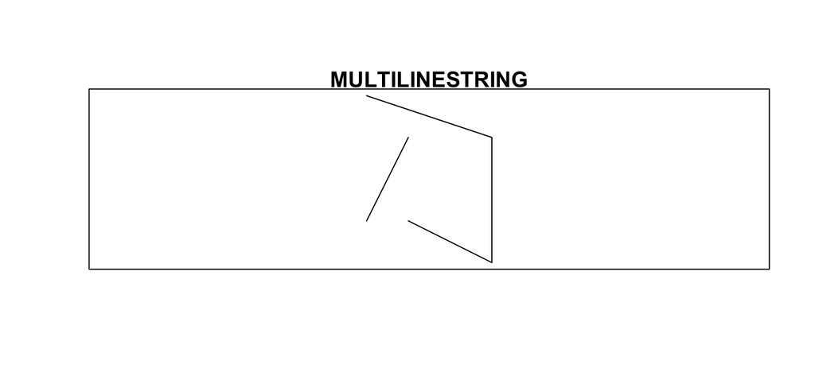

```r
# MULTIPOLYGON
mpyl <- list(list(rbind(c(1, 5), c(2, 2), c(4, 1), c(1, 5))),
            list(rbind(c(0, 2), c(1, 2), c(1, 3), c(0, 3), c(0, 2))))
(mpoly1 <- st_multipolygon(mpyl))
```

```
## MULTIPOLYGON (((1 5, 2 2, 4 1, 1 5)), ((0 2, 1 2, 1 3, 0 3, 0 2)))
```

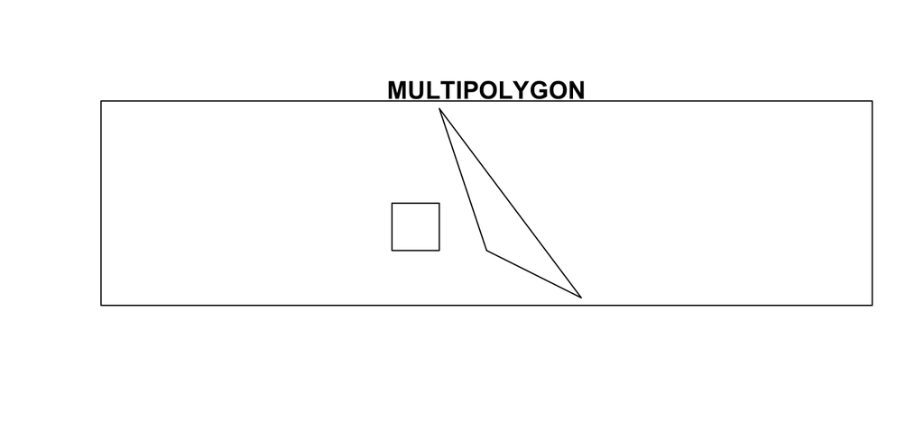

## Combination of geometries

```r
# GEOMETRYCOLLECTION
gcl <- list(ls1, pt1, mpoly1)
(geomcol <- st_geometrycollection(gcl))
```

```
## GEOMETRYCOLLECTION (LINESTRING (5 2, 1 3, 3 4), POINT (5 2), MULTIPOLYGON (((1 5, 2 2, 4 1, 1 5)), ((0 2, 1 2, 1 3, 0 3, 0 2))))
```

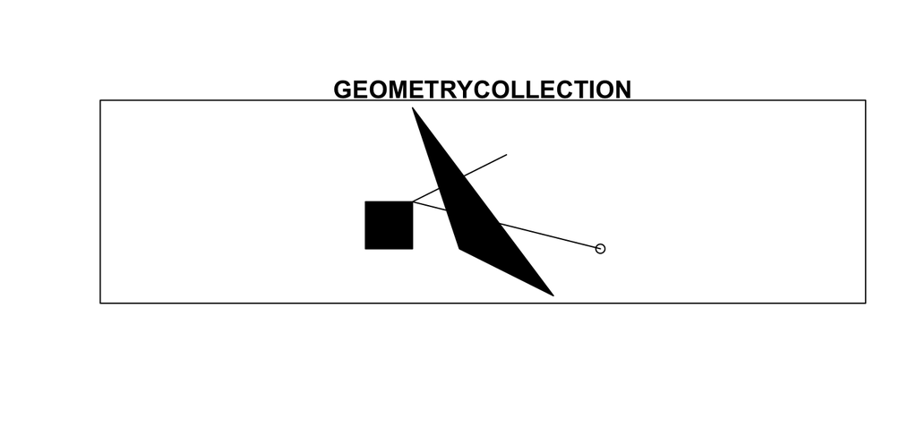

## Building up spatial data frames in R

## From `sfg` to `sfc`

- Objects we’ve made so far have class `sfg`

```r
class(pt1)
```

```
## [1] "XY"    "POINT" "sfg"
```

```r
class(mp1)
```

```
## [1] "XY"         "MULTIPOINT" "sfg"
```

- A **simple feature geometry column** (sfc) is a list of sfg objects
- Important because usually we have more than one feature

## Combine simple features with `st_sfc()`

```r
# sfc POINT
pt1 <- st_point(c(5, 2))
pt2 <- st_point(c(1, 3))
(points_sfc <- st_sfc(pt1, pt2))
```

```
## Geometry set for 2 features
## geometry type:  POINT
## dimension:      XY
## bbox:           xmin: 1 ymin: 2 xmax: 5 ymax: 3
## epsg (SRID):    NA
## proj4string:    NA
```

```
## POINT (5 2)
```

```
## POINT (1 3)
```

```r
class(points_sfc)
```

```
## [1] "sfc_POINT" "sfc"
```

```r
is.list(points_sfc) # is this a list?
```

```
## [1] TRUE
```

```r
is.list(mp1)        # is this (multipoint) a list?
```

```
## [1] FALSE
```

```r
st_geometry_type(points_sfc)
```

```
## [1] POINT POINT
## 18 Levels: GEOMETRY POINT LINESTRING POLYGON MULTIPOINT ... TRIANGLE
```

## From `sfc` to `sf`

- `sfg` and `sfc` only tell you about locations
- to these we add non-geographic attributes associated with each feature
- an `sf` object is a data frame combines these two things:
  - attributes are stored in a regular data.frame
  - location information (co-ordinates) is stored in one (simple feature geometry) column (`sfc`) of this data frame
- Simple features = data frames with spatial attributes stored in a list-column

```r
lnd_point = st_point(c(0.1, 51.5))                 # sfg object
lnd_geom = st_sfc(lnd_point, crs = 4326)           # sfc object
lnd_attrib = data.frame(                           # data.frame object
  name = "London",
  temperature = 25,
  date = as.Date("2017-06-21")
  )
lnd_sf = st_sf(lnd_attrib, geometry = lnd_geom)    # sf object
lnd_sf
```

```
## Simple feature collection with 1 feature and 3 fields
## geometry type:  POINT
## dimension:      XY
## bbox:           xmin: 0.1 ymin: 51.5 xmax: 0.1 ymax: 51.5
## epsg (SRID):    4326
## proj4string:    +proj=longlat +datum=WGS84 +no_defs
##     name temperature       date         geometry
## 1 London          25 2017-06-21 POINT (0.1 51.5)
```

## Coordinate reference systems

## Reprojecting

## Reading in spatial data

## From a shape file

```r
occupancies <- st_read("data/Mongolia_SL_Occ.shp")
occupancies %>% st_crs()     # check the CRS
```

```
## Coordinate Reference System:
##   EPSG: 32648
##   proj4string: "+proj=utm +zone=48 +datum=WGS84 +units=m +no_defs"
```

```r
occupancies <- occupancies %>% st_set_crs("+proj=utm +zone=48 +datum=WGS84 +units=m +no_defs")
occupancies %>% st_crs()
```

```
## Coordinate Reference System:
##   EPSG: 32648
##   proj4string: "+proj=utm +zone=48 +datum=WGS84 +units=m +no_defs"
```

## From a spreadsheet or non-spatial data frame

```r
# g
cams <- read.csv("data/camera-locations.csv")
cams <- st_as_sf(cams, coords = c("Longitude", "Latitude"), crs = 4326)
cams %>% st_crs()
```

```
## Coordinate Reference System:
##   EPSG: 4326
##   proj4string: "+proj=longlat +datum=WGS84 +no_defs"
```

```r
# reprojecting
cams <- cams %>%
  st_transform(crs = "+proj=utm +zone=48 +datum=WGS84 +units=m +no_defs")
```